# Pattern of association between registered covid cases and regsitered number of death

Assignment for Data analysis 2 and Coding with R

Viktória Mészáros

10-26-2020

# Executive summary

In this assignment I looked for the association between confirmed Covid cases and the number of deaths due to Covid. After checking several different possible models I chose a log-log weighted linear regression model, using population as weights as the best representation of the pattern of association between the two variables. With this model we can make the interpretation that if the number of cases is 10% higher, the number of deaths is 9.5% higher, on average.

## Aim of analysis

The aim of this analysis was to look at the pattern of association between registered Covid cases and registered number of death due to Covid from data collected from the start of the pandemic, until October 26, 2020. For this I used two separate data sources. The first data set was a [Covid-19] (https://github.com/CSSEGISandData/COVID-19) data which was collected by Center for Systems Science and Engineering (CSSE) at Johns Hopkins University. The other was population data for 2019 from the World Bank’s site.

Variables in my analysis:

- Outcome variable: Number of registered death
- Explanatory variable: Number of registered cases
- Weight: Population (I will use the population for each county to calculate a weighed model (reg 8))

*All variables are measured as number of people.*

## Data cleaning

Before beiigng able to do analysis on these data, I had to do some cleaning.

*Covid data:*

*Population data:*

- Removed all non-country observations

I merged the two cleaned data tables and also filtered out the variables where population, cases or the number od death was missing.

**My research question is:** “How does the change in the amount of Covid cases effect the number of deaths due to Covid?”

## Quick check on all of my varibles

From the graph we can see that all the distributions for our variables are skewed to the right. Before moving on, we should have a look at the extreme values.

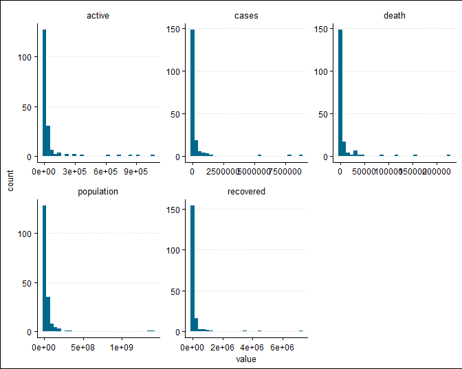

## Extreme values

When I take a closer look on the potential extreme values, I realize the really large numbers for cases and deaths belong to the United States, India and Brazil meaning these are not due to error, but important observations for my analysis, so I do not exclude them. The issue is similar for population. These the large values are China and India which are not extreme values either. There are no unknown values in any variables, as I excluded them during the cleaning phase. There are 14 countries in the data, where the number of deaths were zero. Together these represent 0.004% of the cases and 0.3% of the total population. As the aim of my analysis is to find a pattern between the number of cases and deaths, I decided to exclude those countries from the data.

## Distributions for the x and y variables

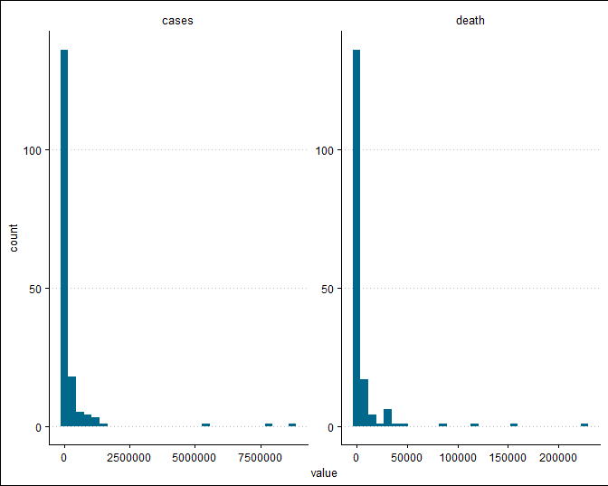

| variable | mean | median | min | max | std | skew | numObs |
| --- | --- | --- | --- | --- | --- | --- | --- |
| Registered Covid cases | 255880.188 | 29054 | 33 | 8726836 | 1005361.07 | 7.0287 | 170 |
| Registered deaths due to Covid | 6817.835 | 439 | 1 | 225938 | 24661.91 | 6.3669 | 170 |

## Possible ln() transformations

Basic scatter-plot showing the number of cases and the number of deaths - **level-level** model without scaling

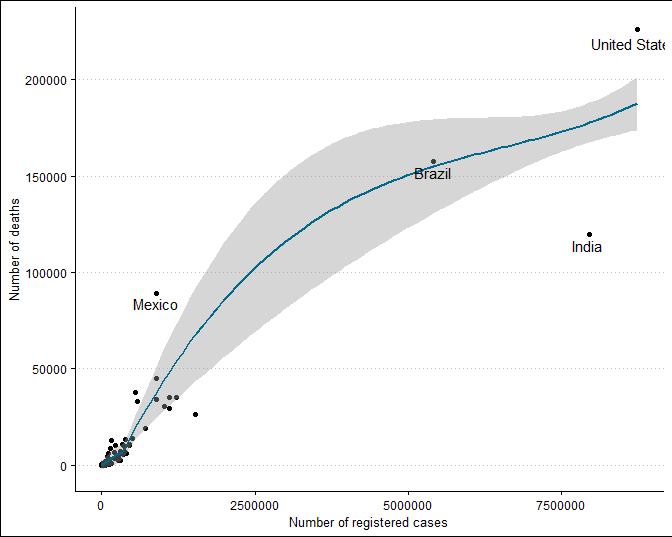

Potential **level-log** model scaling for the number of cases

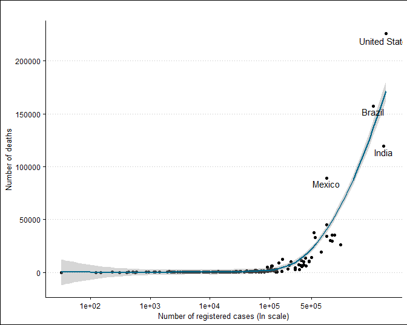

Potential **log-level** model scaling for the number of deaths

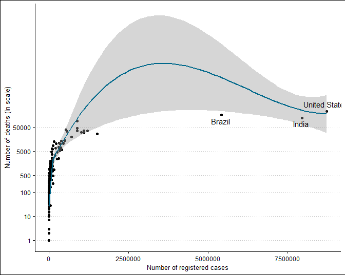

Potential **log-log** model scaling both the number of cases AND deaths

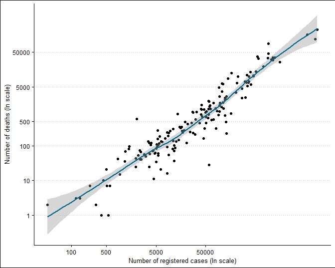

Based on the graphs above I decided to take the log of the number of cases and the number of deaths as well. From a substantive view the number of cases and even deaths can increase by hundreds or thousand each day and so taking them as percentage can make interpretation easier (the variables are affected in a multiplicative way), also as the population of different countries differ significantly, a relative difference could be used better than a unit change. As a statistical reason, the distribution of the variables are skewed to the right, so with a ln() transformation it becomes more symmetric and closer to normal. (To take logs it is important that we only have positive values and as we dropped all zero values it is true for our data.)

## Pattern of association

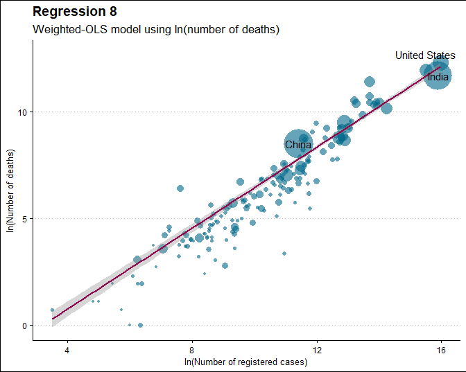

```
##
## Call:
## lm_robust(formula = ln_death ~ ln_cases, data = df, weights = population)
##
## Weighted, Standard error type:  HC2
##
## Coefficients:
##             Estimate Std. Error t value  Pr(>|t|) CI Lower CI Upper  DF
## (Intercept)  -3.0417    0.76953  -3.953 1.137e-04  -4.5609   -1.522 168
## ln_cases      0.9494    0.06067  15.649 1.252e-34   0.8296    1.069 168
##
## Multiple R-squared:  0.9298 ,    Adjusted R-squared:  0.9294
## F-statistic: 244.9 on 1 and 168 DF,  p-value: < 2.2e-16
```

## Test for the slope parameter

I use hypothesis testing on the association between confirmed cases and number of deaths. The null hypothesis is that beta equals zero, while my alternative hypothesis is that it is not zero. Let’s use a 99% confidence interval. The t-value of the test is 15.65 which is out of the 2.6 (99% CI). We can also look at the p-value which is close to zero meaning that the possibility of a false positive error is almost 0%. As a result we can reject the H0 hypothesis that the beta coefficient on log confirmed cases is equal to zero. The correlation between the two variables seems to significant.

Linear hypothesis test

Hypothesis: ln_cases = 0

Model 1: restricted model Model 2: ln_death ~ ln_cases

Res.Df Df Chisq Pr(>Chisq)  
1 169  
2 168 1 244.88 < 2.2e-16 *** — Signif. codes: 0 ‘**’ 0.001 ’**’ 0.01 ’’ 0.05 ‘.’ 0.1 ’ ’ 1

## Analyze residuals

With looking at the residuals we can see which counties had higher or lower ln(number of death) compared what is expected based on out model. The best five countries, where the ln(deaths) is much lower compared to what was expected were Singapore, Burundi, Sri Lanka, Qatar and Liechtenstein. this can mean that these countires manage this pandemic better, compared to other, they have better healthcare system, or made more precautions. On the other hand, the countries, who did the worst were Yemen, Mexico, Ecuador, Italy and Iran. The reason behind can be the bad healthcare system in these countries or the lack of social distancing and other protective measure.

```
## # A tibble: 5 x 4
##   country       ln_death reg8_y_pred reg8_res
##   <chr>            <dbl>       <dbl>    <dbl>
## 1 Singapore         3.33        7.37    -4.04
## 2 Burundi           0           2.96    -2.96
## 3 Sri Lanka         2.77        5.54    -2.77
## 4 Qatar             5.44        8.15    -2.71
## 5 Liechtenstein     0           2.65    -2.65
```

```
## # A tibble: 5 x 4
##   country ln_death reg8_y_pred reg8_res
##   <chr>      <dbl>       <dbl>    <dbl>
## 1 Yemen       6.40        4.20    2.19
## 2 Mexico     11.4         9.97    1.43
## 3 Ecuador     9.44        8.35    1.09
## 4 Italy      10.5         9.49    1.04
## 5 Iran       10.4         9.55    0.854
```

## Conclusion

In this project I investigated the pattern of association between the number of registered Covid cases and the number of deaths due to this disease. I have found a strong correlation between these variables, seeing that if the number of cases are 10% higher, the number of deaths are also almost 10% (9.5% exactly) higher, on average

My analysis could have been strengthened by incorporating some other variables, such as the average age of people died or even a time frame somehow. As the data shows the cases as total until 26th of October, it would be interesting to see how they change with time in the different countries due to governmental rules or other issues. Another weakening factor can be in my analysis that not all the countries report the number of deaths the same time, and there are several cases where the reason behind a death is not purely due to covid. Taking more detaileds into consideration would make the analysis even stronger.

## Appendix I.- All regression models

```
##
## Call:
## lm_robust(formula = death ~ ln_cases, data = df, se_type = "HC2")
##
## Standard error type:  HC2
##
## Coefficients:
##             Estimate Std. Error t value Pr(>|t|) CI Lower CI Upper  DF
## (Intercept)   -49486      15755  -3.141 0.001991   -80590   -18382 168
## ln_cases        5542       1685   3.290 0.001222     2216     8868 168
##
## Multiple R-squared:  0.2576 ,    Adjusted R-squared:  0.2532
## F-statistic: 10.82 on 1 and 168 DF,  p-value: 0.001222
```

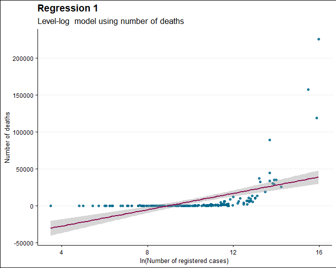

```
##
## Call:
## lm_robust(formula = death ~ ln_cases + ln_cases_2, data = df)
##
## Standard error type:  HC2
##
## Coefficients:
##             Estimate Std. Error t value  Pr(>|t|) CI Lower CI Upper  DF
## (Intercept)   151335    52466.5   2.884 0.0044386  47751.9   254918 167
## ln_cases      -36499    11453.8  -3.187 0.0017184 -59111.5   -13886 167
## ln_cases_2      2090      603.9   3.460 0.0006848    897.5     3282 167
##
## Multiple R-squared:  0.6145 ,    Adjusted R-squared:  0.6099
## F-statistic: 10.89 on 2 and 167 DF,  p-value: 3.57e-05
```

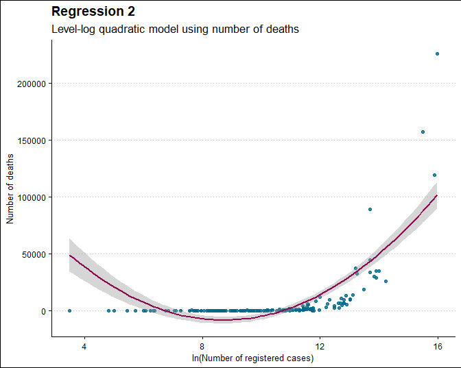

```
##
## Call:
## lm_robust(formula = death ~ ln_cases + ln_cases_2 + ln_cases_3,
##     data = df)
##
## Standard error type:  HC2
##
## Coefficients:
##             Estimate Std. Error t value  Pr(>|t|)  CI Lower CI Upper  DF
## (Intercept)  -230056    97355.9  -2.363 0.0192833 -422271.6 -37840.8 166
## ln_cases       91532    31980.4   2.862 0.0047503   28391.2 154672.7 166
## ln_cases_2    -11396     3423.1  -3.329 0.0010730  -18154.7  -4637.8 166
## ln_cases_3       450      119.3   3.772 0.0002248     214.5    685.6 166
##
## Multiple R-squared:  0.8417 ,    Adjusted R-squared:  0.8389
## F-statistic: 24.63 on 3 and 166 DF,  p-value: 3.095e-13
```

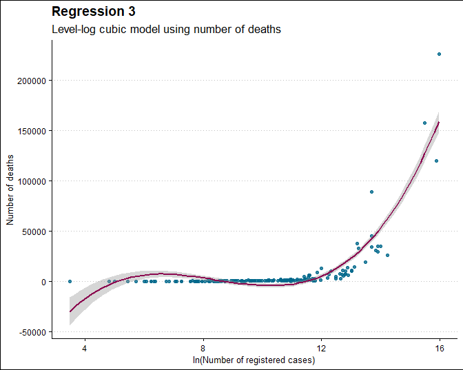

```
##
## Call:
## lm_robust(formula = death ~ lspline(ln_cases, ln_cutoff_1), data = df)
##
## Standard error type:  HC2
##
## Coefficients:
##                                 Estimate Std. Error t value  Pr(>|t|) CI Lower
## (Intercept)                      -6991.2       3162  -2.211 2.840e-02 -13234.3
## lspline(ln_cases, ln_cutoff_1)1    866.6        365   2.374 1.874e-02    145.9
## lspline(ln_cases, ln_cutoff_1)2  56691.7       9909   5.721 4.781e-08  37129.1
##                                 CI Upper  DF
## (Intercept)                       -748.2 167
## lspline(ln_cases, ln_cutoff_1)1   1587.2 167
## lspline(ln_cases, ln_cutoff_1)2  76254.4 167
##
## Multiple R-squared:  0.8716 ,    Adjusted R-squared:   0.87
## F-statistic: 39.27 on 2 and 167 DF,  p-value: 1.049e-14
```

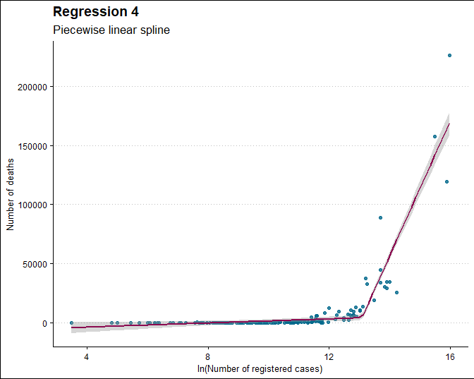

```
##
## Call:
## lm_robust(formula = ln_death ~ ln_cases, data = df)
##
## Standard error type:  HC2
##
## Coefficients:
##             Estimate Std. Error t value  Pr(>|t|) CI Lower CI Upper  DF
## (Intercept)   -4.313     0.3159  -13.66 4.871e-29  -4.9366   -3.689 168
## ln_cases       1.027     0.0293   35.06 3.543e-79   0.9692    1.085 168
##
## Multiple R-squared:  0.8875 ,    Adjusted R-squared:  0.8868
## F-statistic:  1229 on 1 and 168 DF,  p-value: < 2.2e-16
```

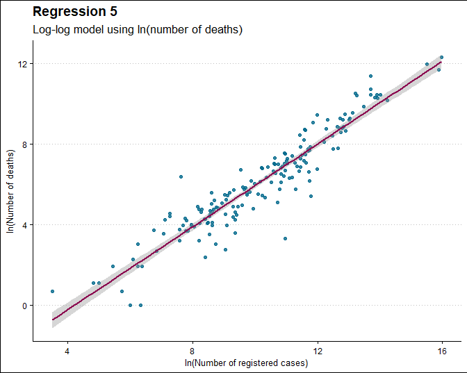

```
##
## Call:
## lm_robust(formula = ln_death ~ ln_cases + ln_cases_2, data = df)
##
## Standard error type:  HC2
##
## Coefficients:
##             Estimate Std. Error t value Pr(>|t|)  CI Lower CI Upper  DF
## (Intercept) -2.03983    0.89323  -2.284 0.023652 -3.803311 -0.27634 167
## ln_cases     0.55117    0.17127   3.218 0.001550  0.213031  0.88931 167
## ln_cases_2   0.02366    0.00809   2.924 0.003935  0.007683  0.03963 167
##
## Multiple R-squared:  0.8921 ,    Adjusted R-squared:  0.8908
## F-statistic: 727.1 on 2 and 167 DF,  p-value: < 2.2e-16
```

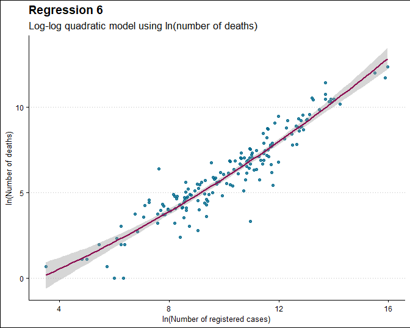

```
##
## Call:
## lm_robust(formula = ln_death ~ ln_cases + ln_cases_2 + ln_cases_3,
##     data = df)
##
## Standard error type:  HC2
##
## Coefficients:
##               Estimate Std. Error t value Pr(>|t|)  CI Lower CI Upper  DF
## (Intercept) -1.4030829   1.734098 -0.8091   0.4196 -4.826813 2.020647 166
## ln_cases     0.3374194   0.568745  0.5933   0.5538 -0.785487 1.460326 166
## ln_cases_2   0.0461703   0.060545  0.7626   0.4468 -0.073367 0.165708 166
## ln_cases_3  -0.0007514   0.002064 -0.3641   0.7162 -0.004826 0.003323 166
##
## Multiple R-squared:  0.8922 ,    Adjusted R-squared:  0.8902
## F-statistic: 503.5 on 3 and 166 DF,  p-value: < 2.2e-16
```

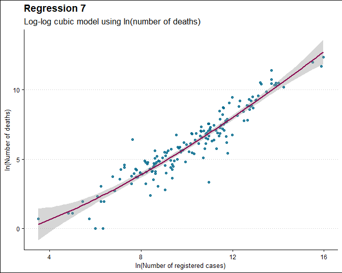

```
##
## Call:
## lm_robust(formula = ln_death ~ ln_cases, data = df, weights = population)
##
## Weighted, Standard error type:  HC2
##
## Coefficients:
##             Estimate Std. Error t value  Pr(>|t|) CI Lower CI Upper  DF
## (Intercept)  -3.0417    0.76953  -3.953 1.137e-04  -4.5609   -1.522 168
## ln_cases      0.9494    0.06067  15.649 1.252e-34   0.8296    1.069 168
##
## Multiple R-squared:  0.9298 ,    Adjusted R-squared:  0.9294
## F-statistic: 244.9 on 1 and 168 DF,  p-value: < 2.2e-16
```

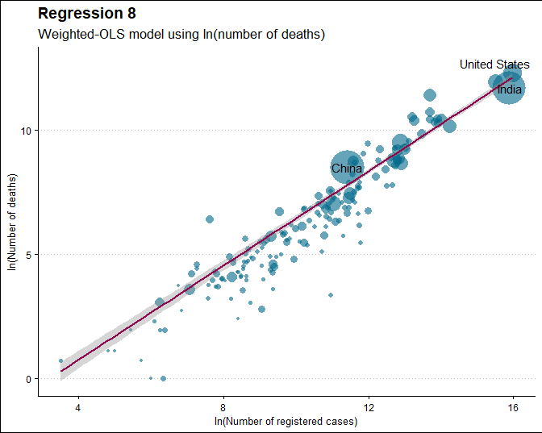

## Appendix II. - Summary Table

```
## The table was written to the file '~/Documents/CEU/Fall_semester/Data_analysis_2/Assignment/Out/model_comparison.html'.
```